# GLMM Analysis for Circle Time

Pourya Shahverdi

2025-07-26

# About the Study

## Introduction to Circle-Time

Circle-time is a group activity based on Applied Behavior Analysis (ABA) for children with Autism Spectrum Disorder (ASD) to prepare them for attending in traditional classroom activities alongside neurotypically developing children. In circle-time, children sit together semicircular, and an instructor gives them group instruction activities such as dance, yoga, labeling animals, finding objects, etc. The goal of circle-time is to improve children’s learning behaviors, which are:

- Affect
- Communication
- Engagement
- Performance

In this study, we evaluate the efficacy of a social robot in delivering group instruction activities to children with ASD. Throughout the six months of experiment, six children participants received 10 sessions of group instructions from a human instructor and 10 sessions from a Pepper humanoid social robot as a within-subject study design. To compare children’s learning behaviors between the human and the robot instructor conditions, their activities were video recorded and coded for sessions 1, 4, 7, and 10.

## Study Design

For this longitudinal within-subject study with 6 participants we defined the following variables:

### Independent Variables

- Instructor Conditions:
  - Human ~ 1
  - Robot ~ 2
- Time:
  - Session 1 ~ 1
  - Session 4 ~ 2
  - Session 7 ~ 3
  - Session 10 ~ 4

### Dependent Variables

- Affect
- Communication
- Engagement
- Performance

## Data Collection

The evaluation of the learning behavior is based on the following continuous metrics:

### Affect

Children’s happiness level was defined as:

- Positive
- Negative
- Neutral

A video was divided into 10-second intervals. A human coder, focusing on one child in the group, labeled that interval as Positive if the child was showing positive affective behaviors (e.g., smiling, clapping, laughing). An interval was labeled as Negative if the child was showing negative affective behaviors (e.g., crying, whining, frowning). Neutral was used when neither applied. The percentage of each type was used for analysis.

### Communication

Communication was coded into 4 categories:

- With Instructor
- Instructor-Prompted
- With Behavior Therapist (BT) or peers
- Indeterminate

### Engagement

Engagement was coded into 3 categories:

- On Target (Instructor or screen)
- With BT or peers
- Off Target

### Performance

Children’s performance was coded as:

- Positive
- Negative

### Inter-observer Agreement (IoA)

Coders were required to exceed 80% Cohen’s Kappa IoA to code independently. All session ones and tens were double-coded, along with 30% of session fours and sevens. Disagreements were resolved through joint review to ensure 100% final agreement.

# Data Analysis

## Additive and Interaction Models and Plots

In this section, we first fit an additive model to evaluate the overall effects of instructor condition (Human vs. Robot), session time, and children’s VB-MAPP scores on each learning behavior. By including VB-MAPP as a covariate, we control for differences in individual skill levels, ensuring a fair comparison of the children’s responses across instructional conditions over time.

Next, we extend the analysis using an interaction model that tests whether the effect of instructor condition varies depending on the session time or the VB-MAPP score. This helps uncover whether certain children or timepoints show stronger effects from robot-led instruction.

Together, these analyses and visualizations offer a comprehensive understanding of how social robot instruction compares to human-led instruction across time and learner profiles.

```r
library(glmmTMB)
library(performance)
library(DHARMa)
```

```
##
## ==============================
## Behavior: Affect_Positive
##
## Additive Model Summary:
## # A tibble: 4 × 6
##   term           estimate std.error statistic p.value stars
##   <chr>             <dbl>     <dbl>     <dbl>   <dbl> <chr>
## 1 (Intercept)      2.23      2.89       0.770 0.441   ""
## 2 ConditionRobot   0.435     0.151      2.89  0.00390 "**"
## 3 time_c          -0.0776    0.0658    -1.18  0.238   ""
## 4 VBMAPP          -2.66      1.79      -1.49  0.138   ""
##
## Interaction Model Summary:
## # A tibble: 6 × 6
##   term                  estimate std.error statistic p.value stars
##   <chr>                    <dbl>     <dbl>     <dbl>   <dbl> <chr>
## 1 (Intercept)             6.01      3.19       1.88  0.0597  "."
## 2 ConditionRobot         -6.28      2.35      -2.67  0.00755 "**"
## 3 time_c                 -0.0472    0.0901    -0.523 0.601   ""
## 4 VBMAPP                 -5.05      1.99      -2.54  0.0112  "*"
## 5 ConditionRobot:time_c  -0.0696    0.121     -0.574 0.566   ""
## 6 ConditionRobot:VBMAPP   4.22      1.48       2.86  0.00426 "**"
```

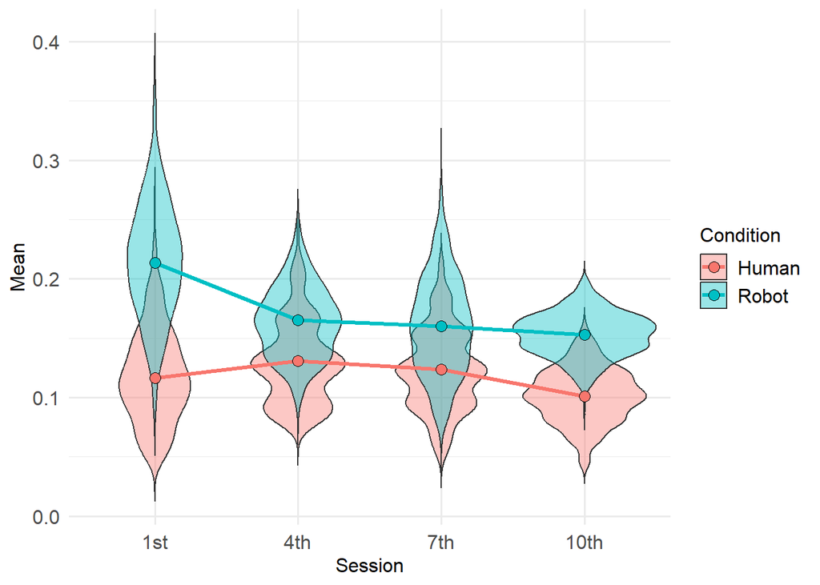

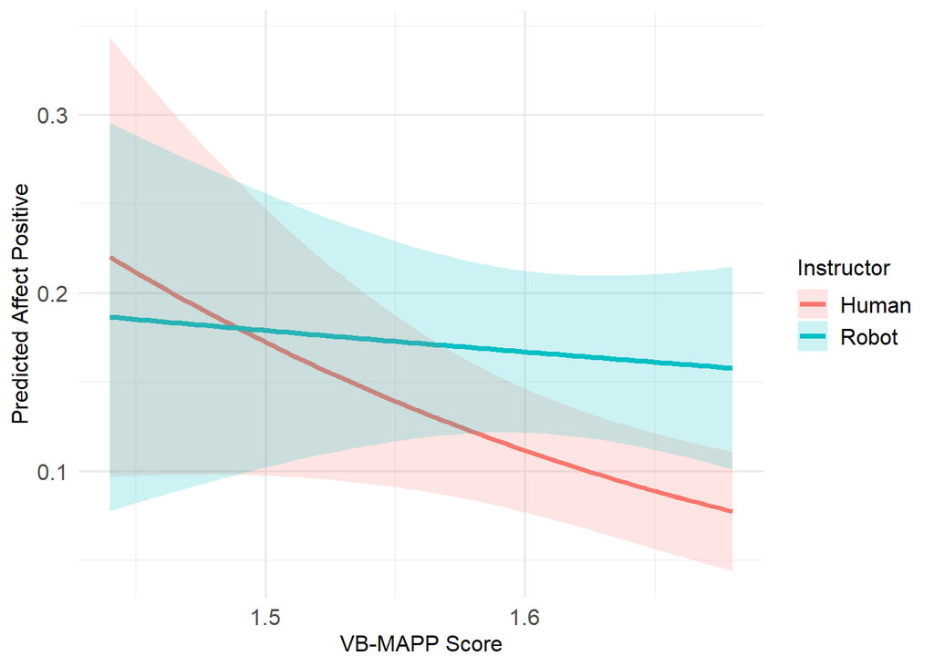

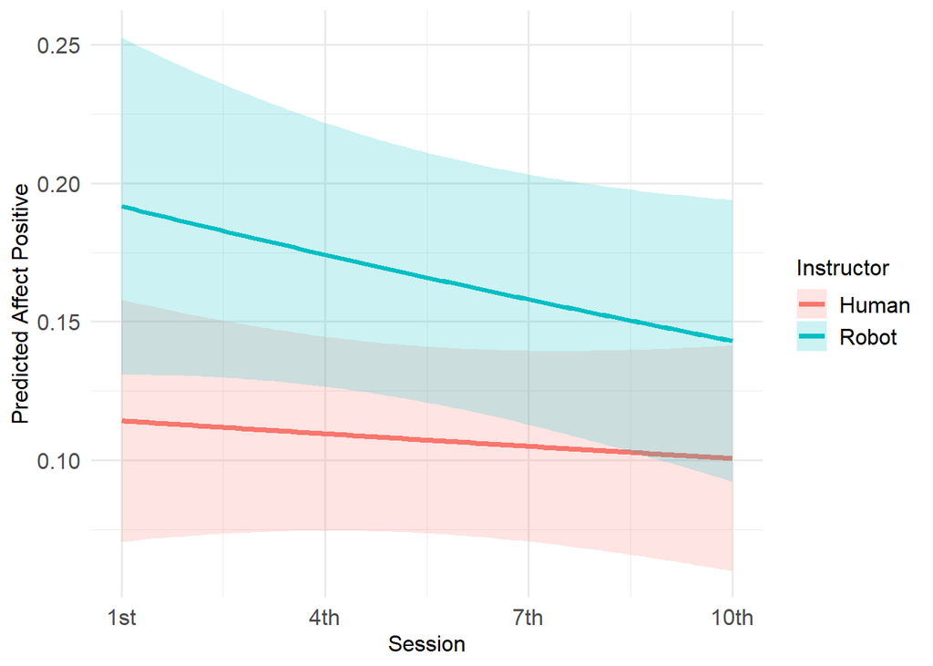

```
##
## ==============================
## Behavior: Affect_Negative
##
## Additive Model Summary:
## # A tibble: 4 × 6
##   term           estimate std.error statistic p.value stars
##   <chr>             <dbl>     <dbl>     <dbl>   <dbl> <chr>
## 1 (Intercept)     -6.42       2.73     -2.35   0.0187 "*"
## 2 ConditionRobot   0.200      0.289     0.693  0.489  ""
## 3 time_c          -0.0267     0.126    -0.212  0.832  ""
## 4 VBMAPP           1.01       1.67      0.604  0.546  ""
##
## Interaction Model Summary:
## # A tibble: 6 × 6
##   term                  estimate std.error statistic p.value stars
##   <chr>                    <dbl>     <dbl>     <dbl>   <dbl> <chr>
## 1 (Intercept)            -6.30       3.73   -1.69     0.0918 "."
## 2 ConditionRobot          0.0218     5.41    0.00403  0.997  ""
## 3 time_c                 -0.120      0.183  -0.658    0.510  ""
## 4 VBMAPP                  0.930      2.30    0.404    0.686  ""
## 5 ConditionRobot:time_c   0.175      0.251   0.699    0.485  ""
## 6 ConditionRobot:VBMAPP   0.110      3.36    0.0329   0.974  ""
```

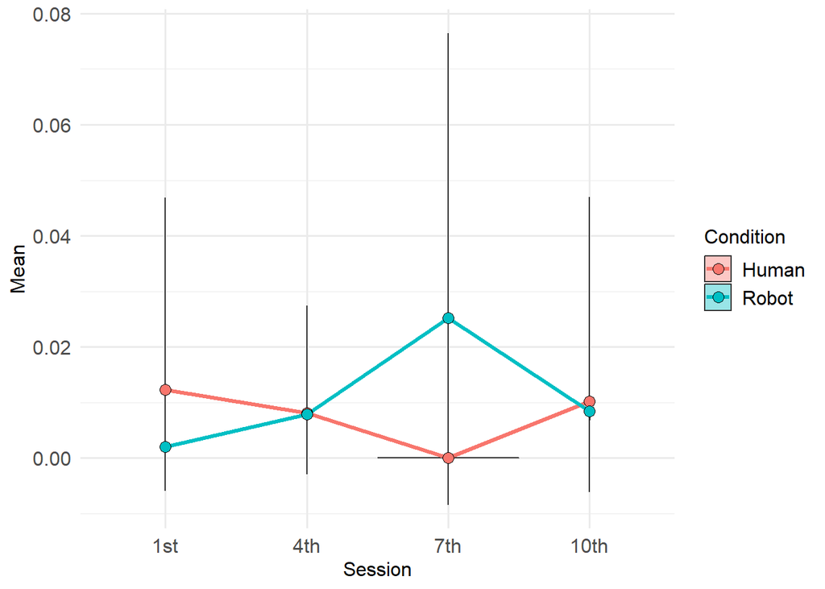

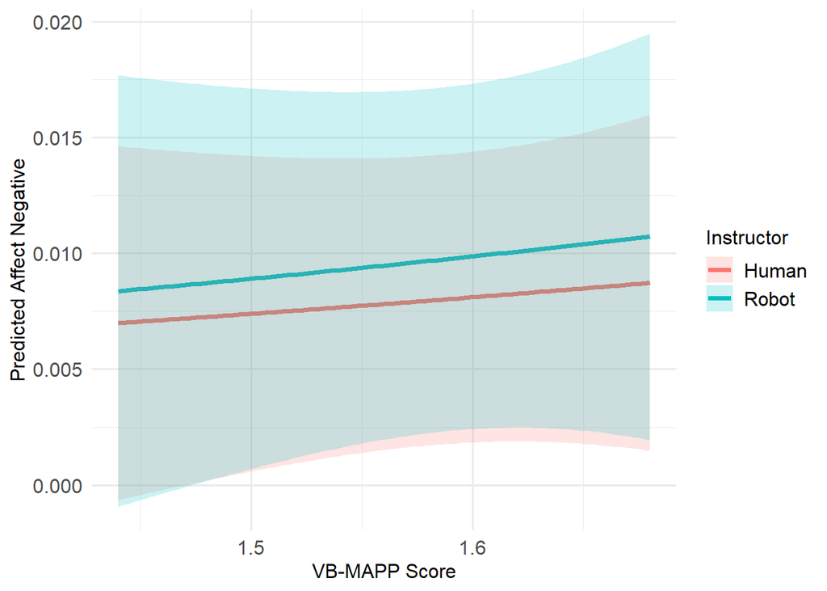

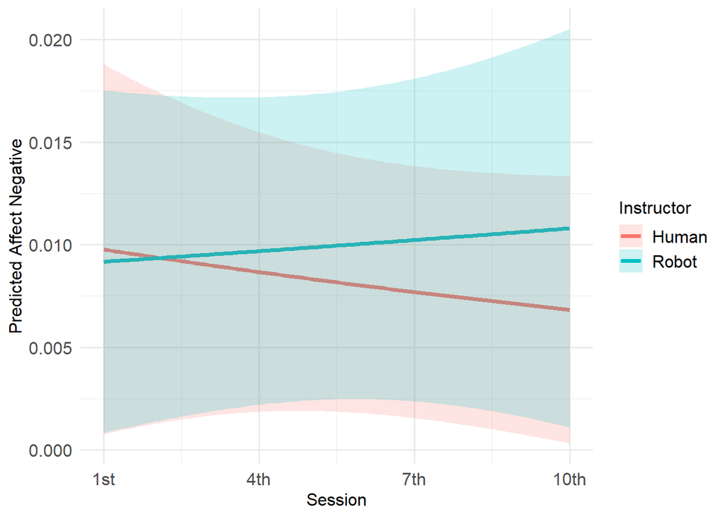

```
##
## ==============================
## Behavior: Communication_with_Instructor
##
## Additive Model Summary:
## # A tibble: 4 × 6
##   term           estimate std.error statistic p.value stars
##   <chr>             <dbl>     <dbl>     <dbl>   <dbl> <chr>
## 1 (Intercept)     -3.81      2.25      -1.69   0.0901 "."
## 2 ConditionRobot  -0.136     0.131     -1.04   0.298  ""
## 3 time_c          -0.0790    0.0594    -1.33   0.183  ""
## 4 VBMAPP           1.06      1.39       0.763  0.445  ""
##
## Interaction Model Summary:
## # A tibble: 6 × 6
##   term                  estimate std.error statistic p.value stars
##   <chr>                    <dbl>     <dbl>     <dbl>   <dbl> <chr>
## 1 (Intercept)           -3.84       2.65     -1.45     0.147 ""
## 2 ConditionRobot        -0.254      2.54     -0.100    0.920 ""
## 3 time_c                 0.00200    0.0797    0.0251   0.980 ""
## 4 VBMAPP                 1.08       1.64      0.659    0.510 ""
## 5 ConditionRobot:time_c -0.170      0.116    -1.46     0.143 ""
## 6 ConditionRobot:VBMAPP  0.0668     1.57      0.0425   0.966 ""
```

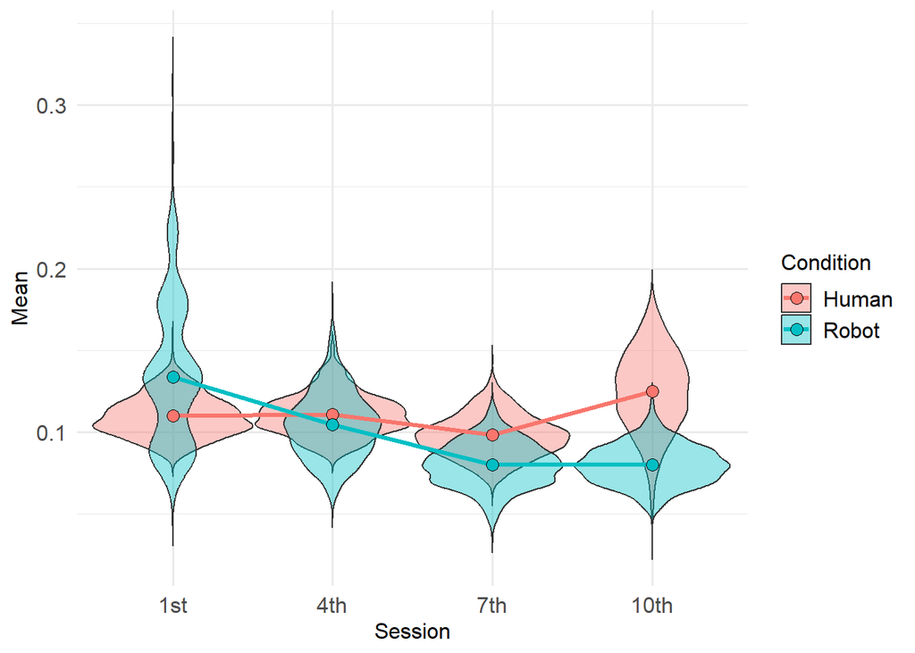

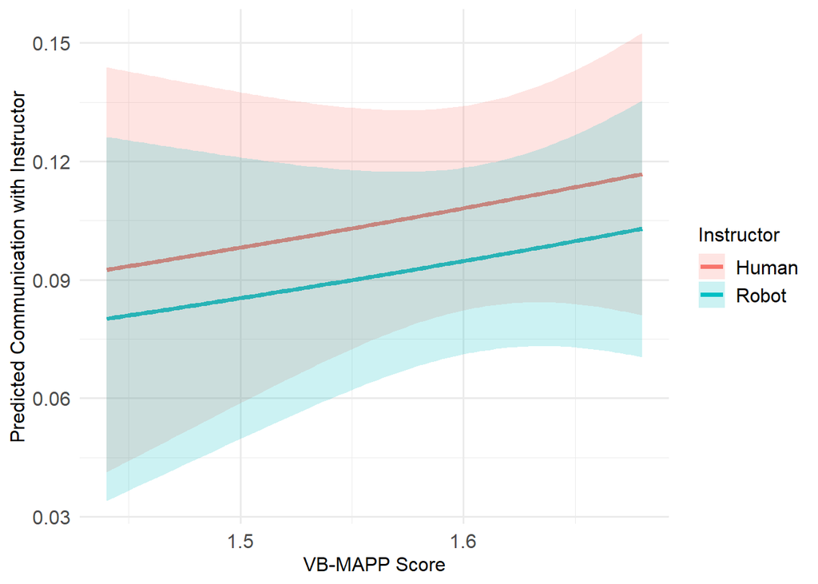

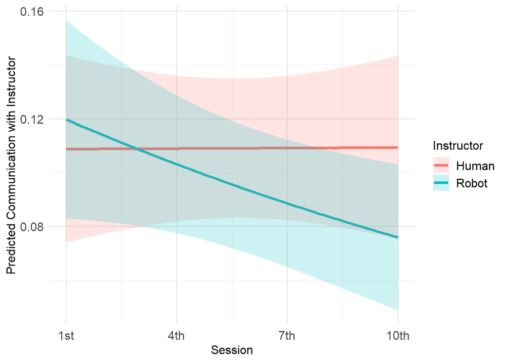

```
##
## ==============================
## Behavior: Communication_with_Instructor_Prompted
##
## Additive Model Summary:
## # A tibble: 4 × 6
##   term           estimate std.error statistic p.value stars
##   <chr>             <dbl>     <dbl>     <dbl>   <dbl> <chr>
## 1 (Intercept)      -2.70      3.05     -0.884   0.377 ""
## 2 ConditionRobot    0.239     0.313     0.762   0.446 ""
## 3 time_c           -0.178     0.124    -1.44    0.150 ""
## 4 VBMAPP           -1.36      1.94     -0.702   0.482 ""
##
## Interaction Model Summary:
## # A tibble: 6 × 6
##   term                  estimate std.error statistic p.value stars
##   <chr>                    <dbl>     <dbl>     <dbl>   <dbl> <chr>
## 1 (Intercept)           -11.2        4.62     -2.43  0.0152  "*"
## 2 ConditionRobot         17.8        5.88      3.03  0.00246 "**"
## 3 time_c                 -0.0287     0.153    -0.187 0.851   ""
## 4 VBMAPP                  3.84       2.85      1.35  0.178   ""
## 5 ConditionRobot:time_c  -0.337      0.242    -1.39  0.163   ""
## 6 ConditionRobot:VBMAPP -10.9        3.66     -2.99  0.00283 "**"
```

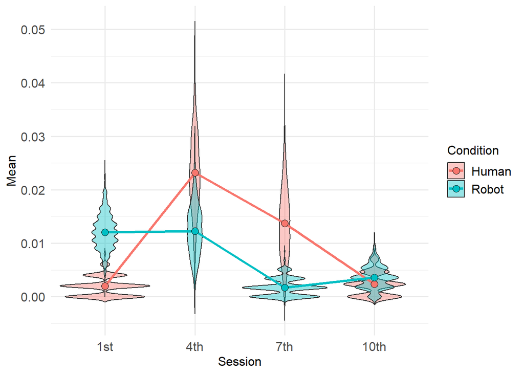

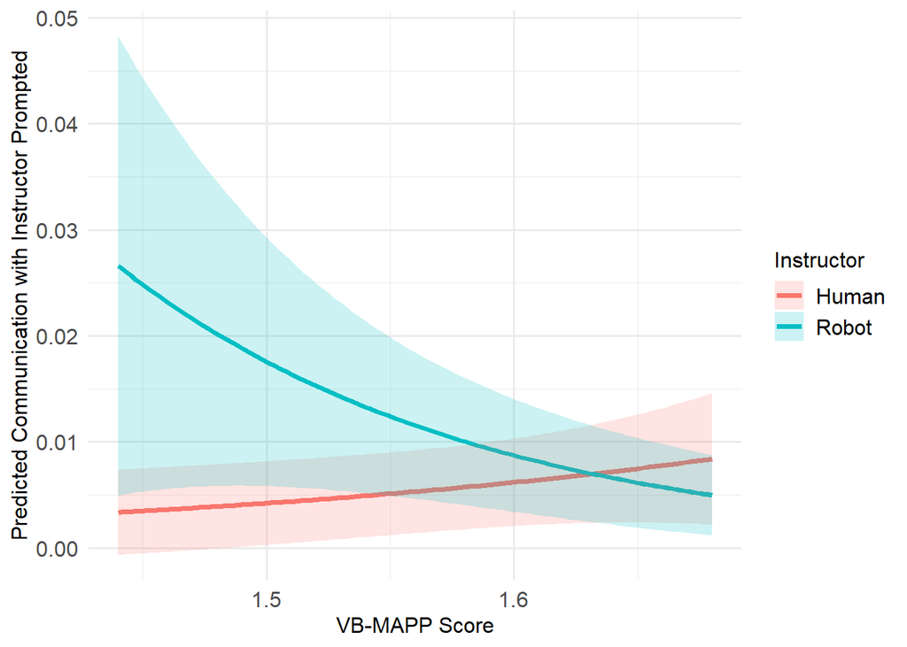

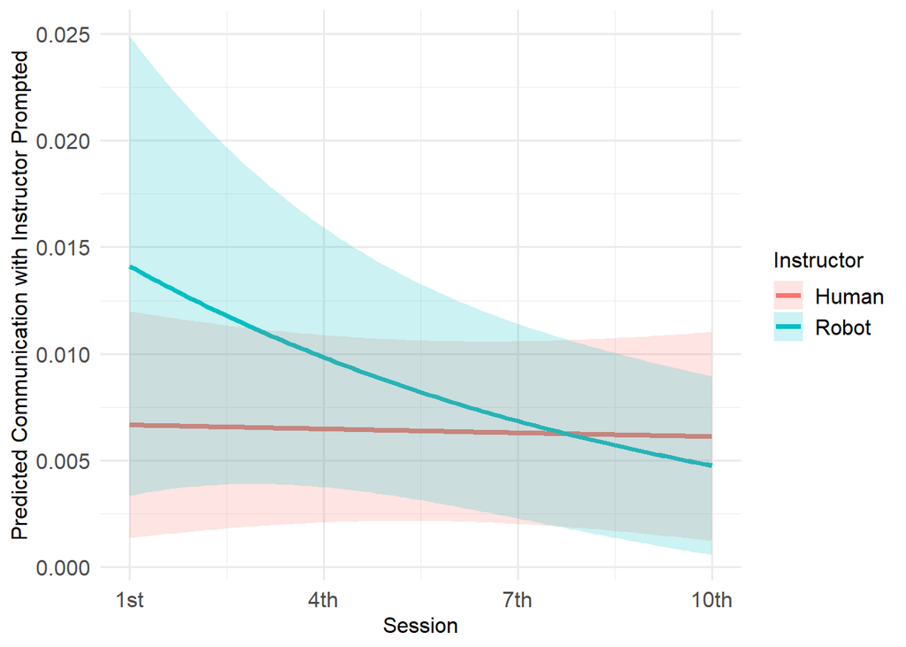

```
##
## ==============================
## Behavior: Communication_with_Therapist
##
## Additive Model Summary:
## # A tibble: 4 × 6
##   term           estimate std.error statistic   p.value stars
##   <chr>             <dbl>     <dbl>     <dbl>     <dbl> <chr>
## 1 (Intercept)      3.57       2.04      1.75  0.0805    "."
## 2 ConditionRobot   0.0322     0.226     0.143 0.887     ""
## 3 time_c          -0.450      0.113    -3.97  0.0000705 "***"
## 4 VBMAPP          -3.92       1.27     -3.07  0.00211   "**"
##
## Interaction Model Summary:
## # A tibble: 6 × 6
##   term                  estimate std.error statistic  p.value stars
##   <chr>                    <dbl>     <dbl>     <dbl>    <dbl> <chr>
## 1 (Intercept)              5.84      2.75       2.13 0.0334   "*"
## 2 ConditionRobot          -4.87      3.85      -1.26 0.207    ""
## 3 time_c                  -0.544     0.142     -3.83 0.000126 "***"
## 4 VBMAPP                  -5.37      1.73      -3.11 0.00186  "**"
## 5 ConditionRobot:time_c    0.208     0.187      1.11 0.266    ""
## 6 ConditionRobot:VBMAPP    3.11      2.41       1.29 0.197    ""
```

[18 more figures not shown]

```r
library(ggplot2)
library(broom.mixed)
library(dplyr)
library(boot)
library(tidyr)

# Load and preprocess data
df <- read.csv("~/GitHub/Circle-Time-Data-Analyses/CircleTimeData-VBMAPP.csv")
df$Condition <- factor(df$Condition, levels = c(1, 2), labels = c("Human", "Robot"))
df$time_c <- scale(df$time, center = TRUE, scale = FALSE)

vars <- c(
  "Affect_Positive", "Affect_Negative",
  "Communication_with_Instructor", "Communication_with_Instructor_Prompted",
  "Communication_with_Therapist", "Communication_with_Indeterminent",
  "Engagement_OnTarget", "Engagement_Therapist", "Engagement_OffTarget",
  "Performance_Positive"
)

# Apply beta transformation
epsilon <- 0.0001
for (v in vars) {
  df[[v]] <- (df[[v]] * (nrow(df) - 1) + epsilon) / nrow(df)
}

# Significance stars function
sig_stars <- function(p) {
  if (is.na(p)) return("")
  if (p < 0.001) return("***")
  else if (p < 0.01) return("**")
  else if (p < 0.05) return("*")
  else if (p < 0.1) return(".")
  else return("")
}

## Additive and Interaction Models and Plots ##
## This section evaluates the behavioral metrics of interest (e.g., Affect, Engagement) through two modeling approaches:
## 1. An additive model controlling for VB-MAPP scores.
## 2. An interaction model examining moderation effects of Condition with time and VB-MAPP.
##
## We then visualize the bootstrapped confidence distributions using violin plots, mean trends, and the interaction effects with VB-MAPP.

for (var in vars) {
  cat("\n==============================\n")
  cat("Behavior:", var, "\n")

  # --- Additive Model ---
  form_add <- as.formula(paste0(var, " ~ Condition + time_c + VBMAPP + (1 | Subject)"))
  model_add <- glmmTMB(form_add, data = df, family = beta_family())

  table_add <- broom.mixed::tidy(model_add, effects = "fixed")
  table_add$stars <- sapply(table_add$p.value, sig_stars)

  cat("\nAdditive Model Summary:\n")
  print(table_add[, c("term", "estimate", "std.error", "statistic", "p.value", "stars")])

  # --- Interaction Model ---
  form_int <- as.formula(paste0(var, " ~ Condition * time_c + Condition * VBMAPP + (1 | Subject)"))
  model_int <- glmmTMB(form_int, data = df, family = beta_family())

  table_int <- broom.mixed::tidy(model_int, effects = "fixed")
  table_int$stars <- sapply(table_int$p.value, sig_stars)

  cat("\nInteraction Model Summary:\n")
  print(table_int[, c("term", "estimate", "std.error", "statistic", "p.value", "stars")])

  # --- Bootstrap Violin Plots with Mean Line ---
  mean_df <- df %>%
    group_by(Condition, time) %>%
    summarise(mean_value = mean(.data[[var]]), .groups = "drop")

  bootstrap_samples <- df %>%
    group_by(Condition, time) %>%
    group_modify(~ {
      boot_result <- boot(.x[[var]], statistic = function(d, i) mean(d[i]), R = 1000)
      tibble(bootstrap = boot_result$t[, 1])
    }) %>%
    ungroup()

  p_violin_line <- ggplot() +
    geom_violin(
      data = bootstrap_samples,
      aes(x = factor(time), y = bootstrap, fill = Condition),
      position = position_identity(),
      alpha = 0.4,
      trim = FALSE,
      width = 1
    ) +
    geom_line(
      data = mean_df,
      aes(x = as.numeric(factor(time)), y = mean_value, color = Condition, group = Condition),
      linewidth = 1.2
    ) +
    geom_point(
      data = mean_df,
      aes(x = as.numeric(factor(time)), y = mean_value, fill = Condition),
      color = "black",
      shape = 21,
      size = 3
    ) +
    scale_x_discrete(
      name = "Session",
      labels = c("1st", "4th", "7th", "10th")
    ) +
    labs(
      # title = paste(var, "– Confidence Distributions with Mean Trends"),
      y = "Mean",
      fill = "Condition",
      color = "Condition"
    ) +
      theme_minimal(base_size = 12) +
  theme(
    plot.title = element_text(size = 12),
    axis.title = element_text(size = 12),
    axis.text = element_text(size = 12),
    legend.title = element_text(size = 12),
    legend.text = element_text(size = 12)
  )

  print(p_violin_line)

    # Define a safe filename using the variable name
  pdf_filename <- paste0("figures/violin_", var, ".pdf")

  # Open PDF device
  pdf(pdf_filename, width = 6, height = 4)

  # Print plot to device
  print(p_violin_line)

  # Close device
  dev.off()


  # --- VB-MAPP Interaction Plot ---
  new_data <- expand.grid(
    Condition = factor(c("Human", "Robot"), levels = c("Human", "Robot")),
    time_c = 0,
    VBMAPP = seq(min(df$VBMAPP), max(df$VBMAPP), length.out = 100),
    Subject = NA
  )
  pred <- predict(model_int, newdata = new_data, type = "response", se.fit = TRUE)
  new_data$predicted <- pred$fit
  new_data$conf.low <- pred$fit - 1.96 * pred$se.fit
  new_data$conf.high <- pred$fit + 1.96 * pred$se.fit
  new_data$group <- new_data$Condition

  p2 <- ggplot(new_data, aes(x = VBMAPP, y = predicted, color = group)) +
    geom_line(size = 1.3) +
    geom_ribbon(aes(ymin = conf.low, ymax = conf.high, fill = group), alpha = 0.2, color = NA) +
    labs(
      x = "VB-MAPP Score",
      y = paste("Predicted", gsub("_", " ", var)),
      color = "Instructor",
      fill = "Instructor",
      # title = paste("Interaction of VB-MAPP and Instructor on", gsub("_", " ", var))
    ) +
    theme_minimal(base_size = 12) +
  theme(
    plot.title = element_text(size = 12),
    axis.title = element_text(size = 12),
    axis.text = element_text(size = 12),
    legend.title = element_text(size = 12),
    legend.text = element_text(size = 12)
  )

  print(p2)

    # Define a safe filename using the variable name
  pdf_filename <- paste0("figures/vbmapp_interaction_", var, ".pdf")

  # Open PDF device
  pdf(pdf_filename, width = 6, height = 4)

  # Print plot to device
  print(p2)

  # Close device
  dev.off()


# --- Time Interaction Plot ---
# Get the original mean-centered values to restore actual session labels
original_session_values <- sort(unique(df$time))
original_session_labels <- c("1st", "4th", "7th", "10th")

new_time_data <- expand.grid(
  Condition = factor(c("Human", "Robot"), levels = c("Human", "Robot")),
  time_c = seq(min(df$time_c), max(df$time_c), length.out = 100),
  VBMAPP = mean(df$VBMAPP, na.rm = TRUE),
  Subject = NA
)

pred_time <- predict(model_int, newdata = new_time_data, type = "response", se.fit = TRUE)
new_time_data$predicted <- pred_time$fit
new_time_data$conf.low <- pred_time$fit - 1.96 * pred_time$se.fit
new_time_data$conf.high <- pred_time$fit + 1.96 * pred_time$se.fit
new_time_data$group <- new_time_data$Condition

# Reconstruct session number from time_c by adding the mean back
mean_time <- mean(df$time)
new_time_data$Session <- new_time_data$time_c + mean_time

p_time <- ggplot(new_time_data, aes(x = Session, y = predicted, color = group)) +
  geom_line(size = 1.3) +
  geom_ribbon(aes(ymin = conf.low, ymax = conf.high, fill = group), alpha = 0.2, color = NA) +
  scale_x_continuous(
    breaks = original_session_values,
    labels = original_session_labels
  ) +
  labs(
    x = "Session",
    y = paste("Predicted", gsub("_", " ", var)),
    color = "Instructor",
    fill = "Instructor"
  ) +
  theme_minimal(base_size = 12) +
  theme(
    axis.title = element_text(size = 12),
    axis.text = element_text(size = 12),
    legend.title = element_text(size = 12),
    legend.text = element_text(size = 12)
  )

print(p_time)

# Save to PDF
pdf_filename <- paste0("figures/time_interaction_", var, ".pdf")
pdf(pdf_filename, width = 6, height = 4)
print(p_time)
dev.off()

}
```

## Results: Additive Model Comparison Between Human and Robot Instructors

To evaluate the effect of instructor type on children’s learning behaviors, we fitted additive generalized linear mixed models (GLMMs) with `Condition` (Human vs. Robot) as a fixed effect, controlling for session time (`time_c`) and individual skill level (`VB-MAPP`). A random intercept for `Subject` accounted for repeated measures. All dependent variables were modeled with a beta distribution to account for their bounded, proportional nature. Below we report the estimated effect of the Robot condition (`ConditionRobot`) relative to the Human condition for each behavioral outcome.

First, let’s take a look at the hexagonal plots from each metric:

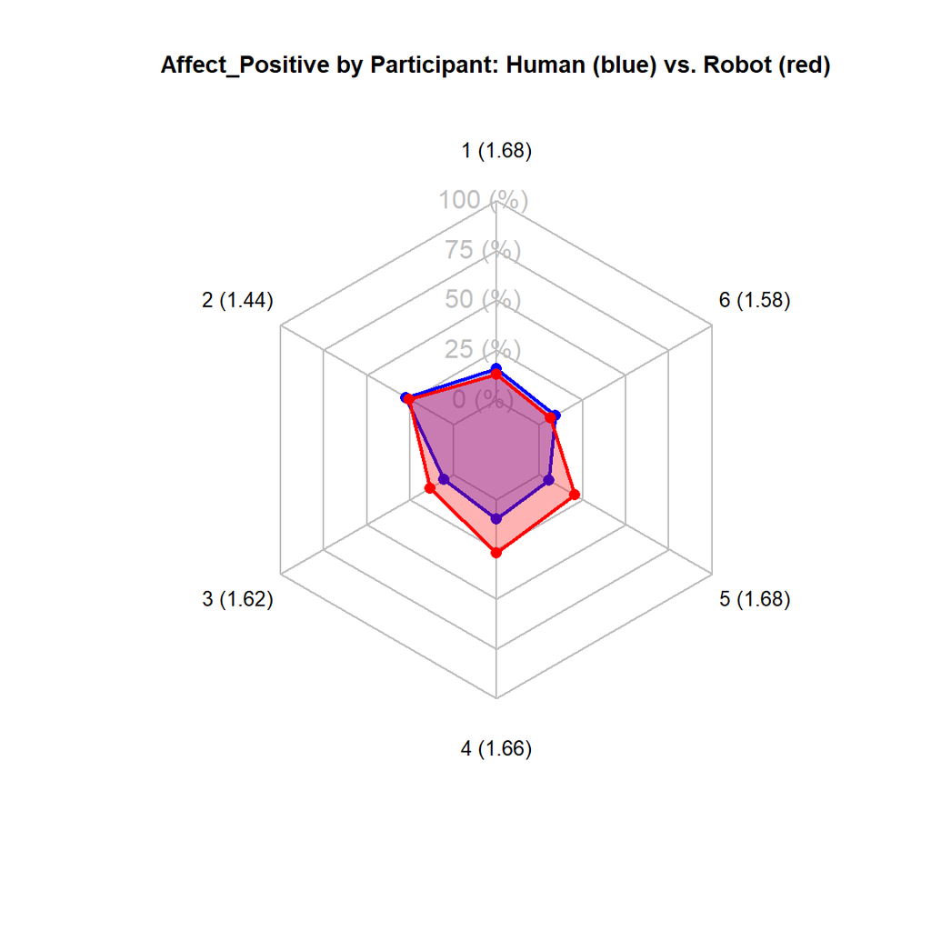

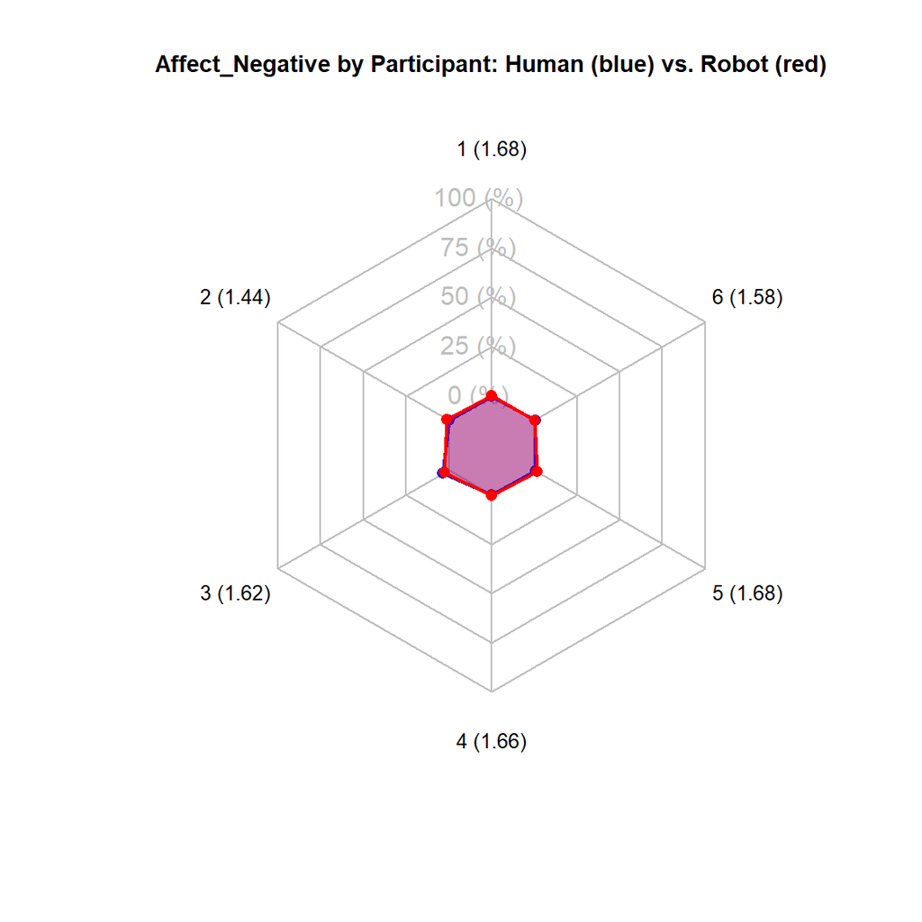

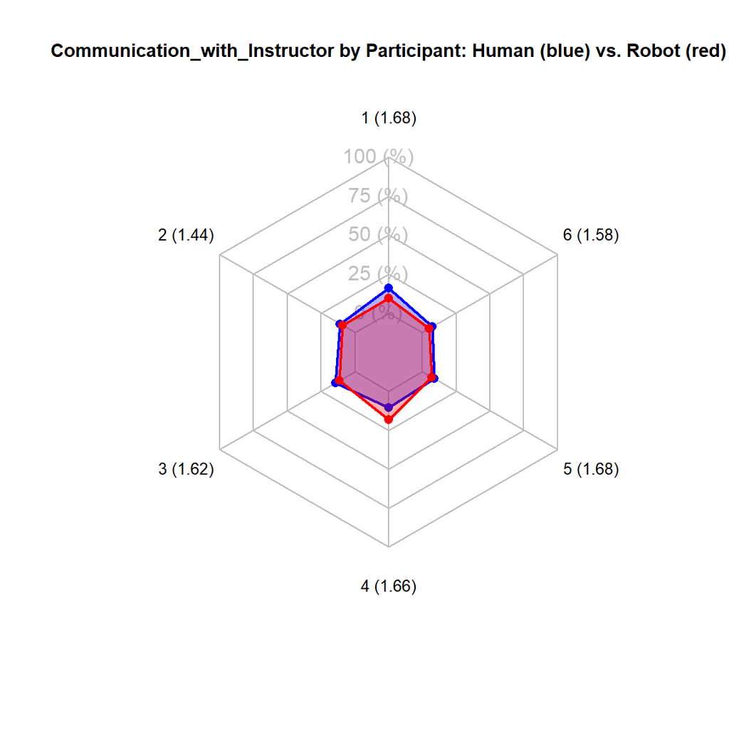

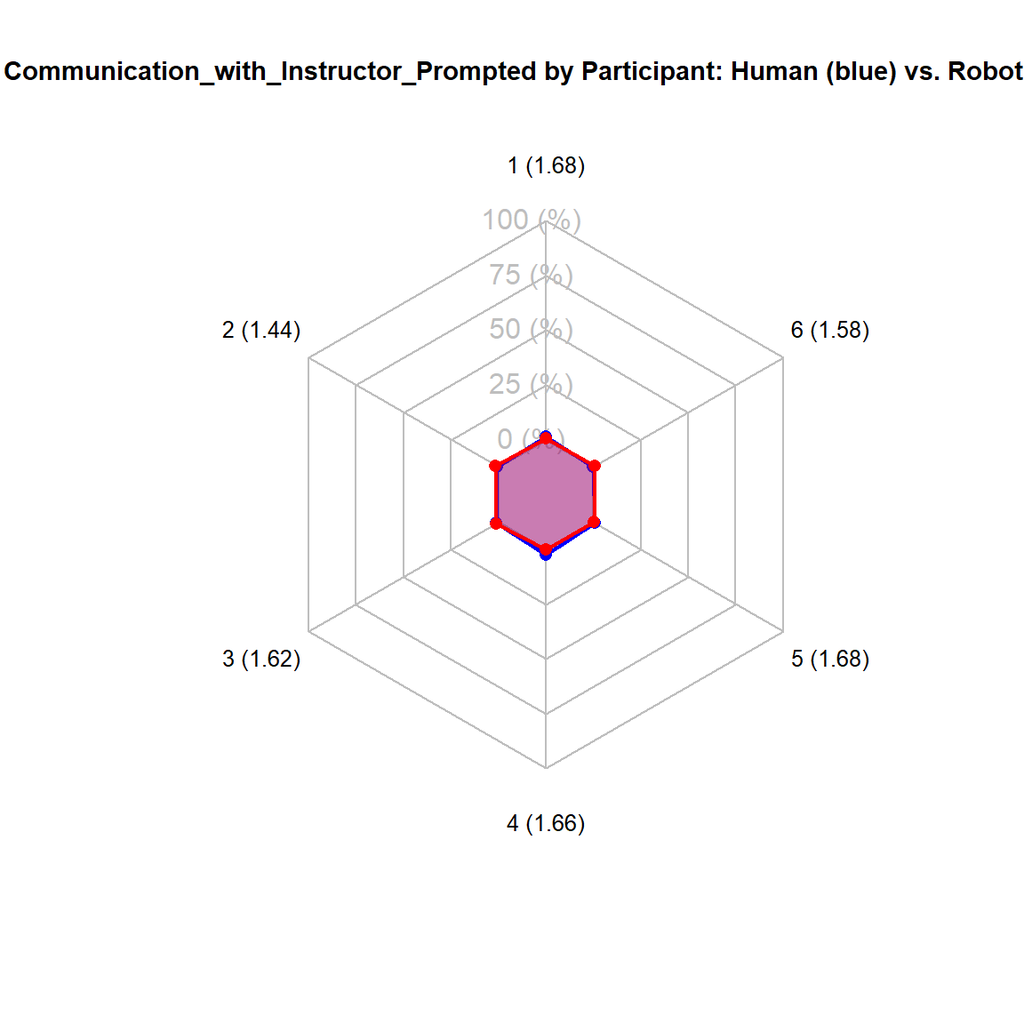

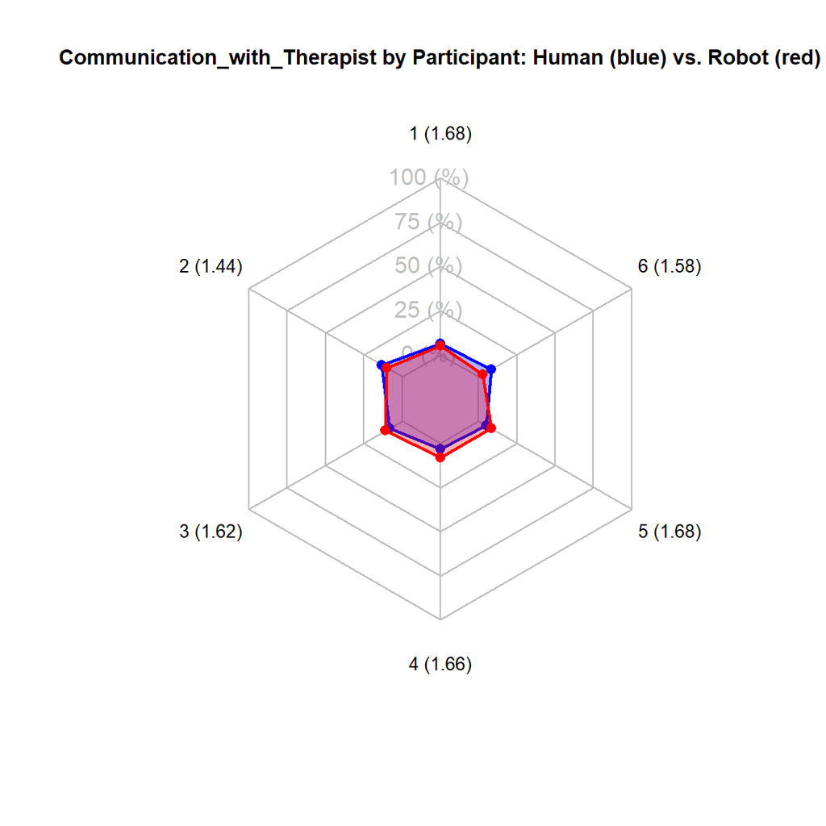

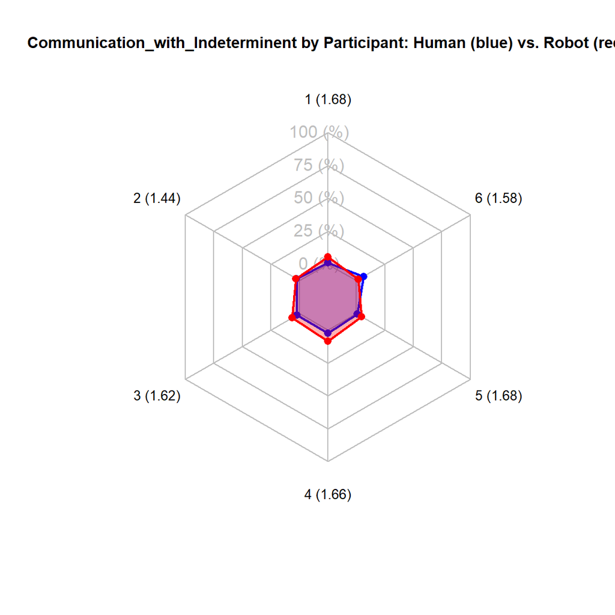

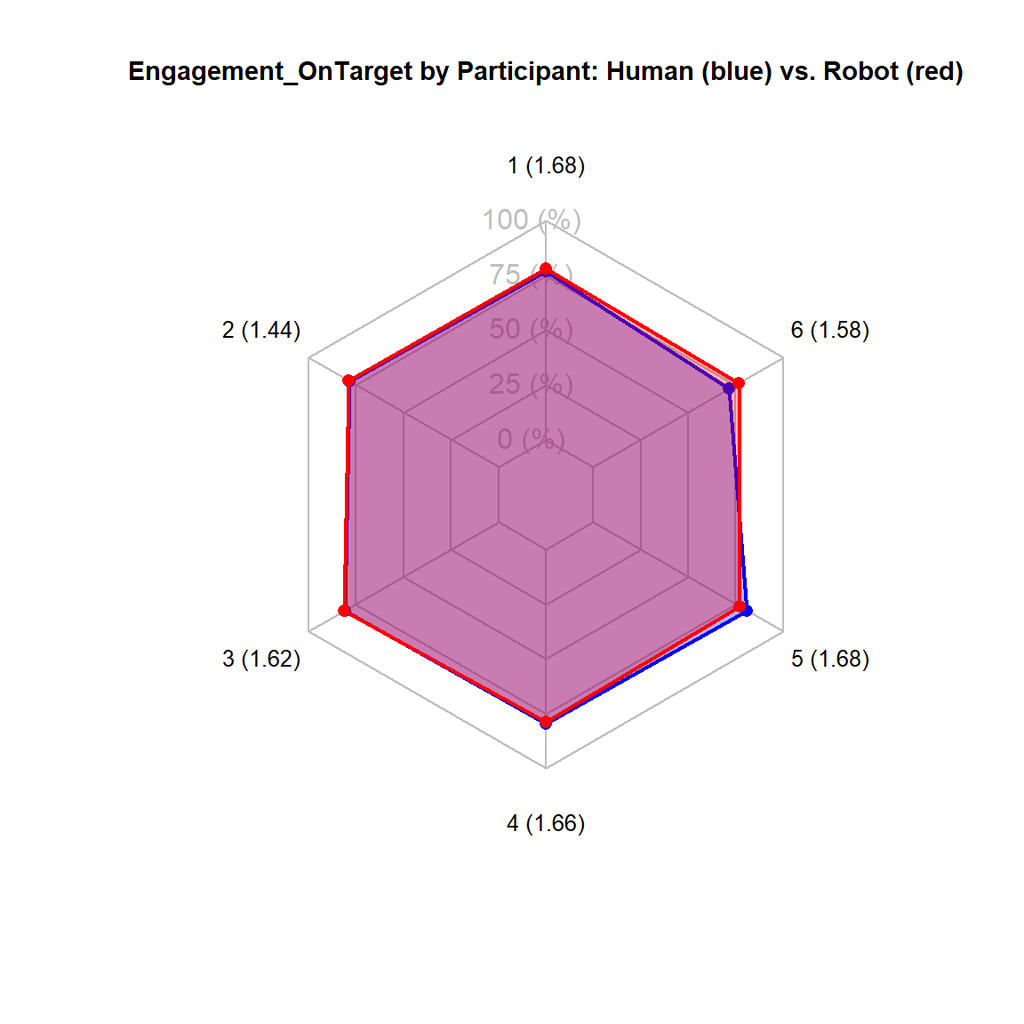

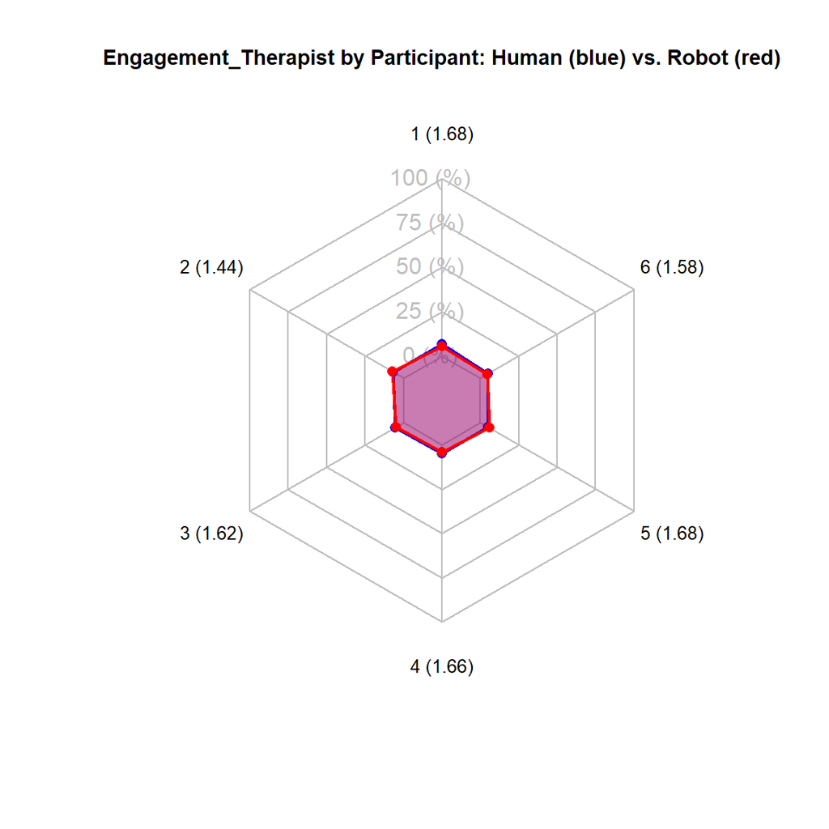

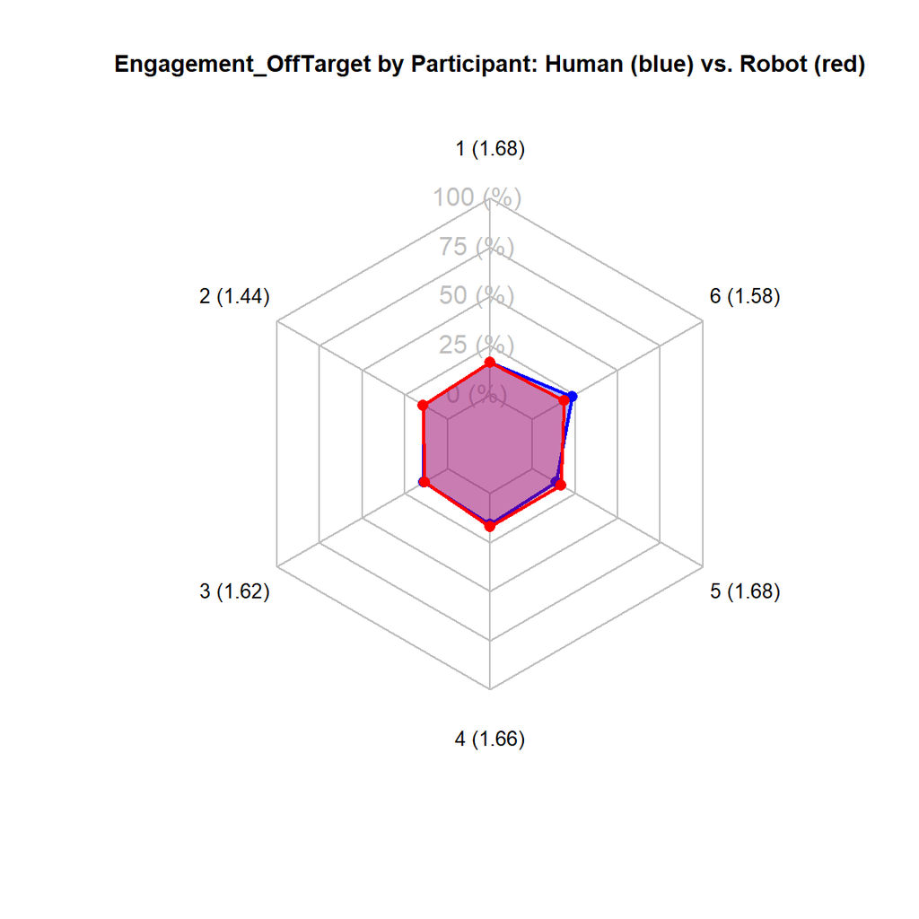

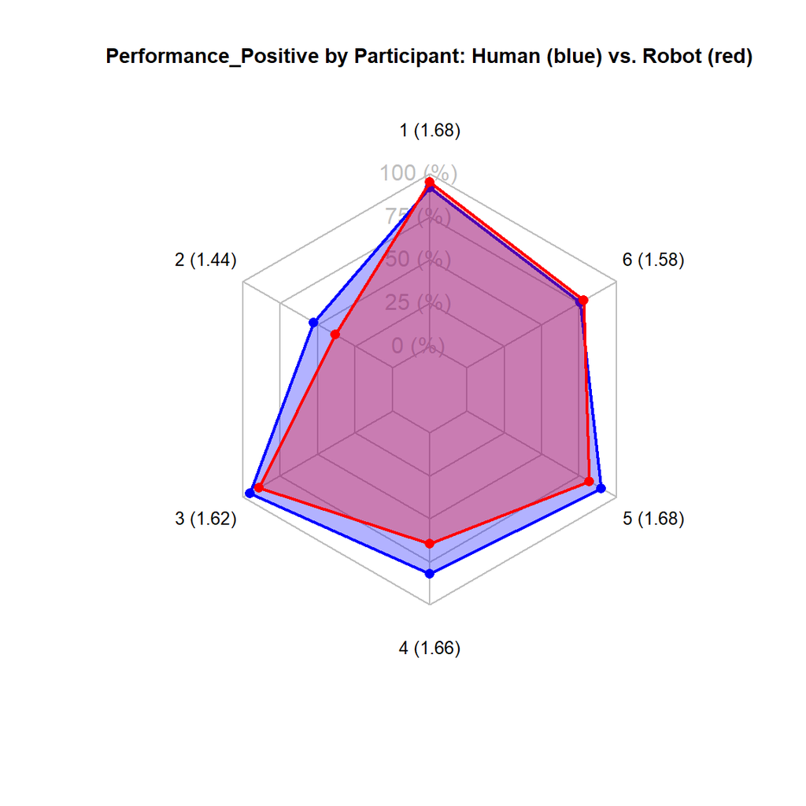

```r
if (!requireNamespace("fmsb", quietly = TRUE)) install.packages("fmsb")
library(fmsb)
library(dplyr)
library(tidyr)

# Load dataset
df <- read.csv("~/GitHub/Circle-Time-Data-Analyses/CircleTimeData-VBMAPP.csv")
df$Condition <- factor(df$Condition, levels = c(1, 2), labels = c("Human", "Robot"))

# Compute unique VBMAPP scores per participant
vbmapp_scores <- df %>%
  group_by(Subject) %>%
  summarise(VBMAPP = mean(VBMAPP, na.rm = TRUE), .groups = "drop")

# List of metrics to visualize
metrics <- c(
  "Affect_Positive", "Affect_Negative",
  "Communication_with_Instructor", "Communication_with_Instructor_Prompted",
  "Communication_with_Therapist", "Communication_with_Indeterminent",
  "Engagement_OnTarget", "Engagement_Therapist", "Engagement_OffTarget",
  "Performance_Positive"
)

for (metric in metrics) {
  # Compute mean metric per participant per condition
  avg_df <- df %>%
    group_by(Subject, Condition) %>%
    summarise(value = mean(.data[[metric]], na.rm = TRUE), .groups = "drop") %>%
    pivot_wider(names_from = Condition, values_from = value) %>%
    inner_join(vbmapp_scores, by = "Subject")

  # Skip if any condition is missing
  if (any(!c("Human", "Robot") %in% colnames(avg_df))) next

  # Sort by Subject ID
  avg_df <- avg_df[order(avg_df$Subject), ]
  human <- avg_df$Human
  robot <- avg_df$Robot

  # Build labels with VBMAPP: e.g., "P1 (1.55)"
  axis_labels <- paste0(avg_df$Subject, " (", round(avg_df$VBMAPP, 2), ")")

  # Assemble data
  data <- as.data.frame(rbind(
    rep(1, length(human)),
    rep(0, length(human)),
    human,
    robot
  ))
  colnames(data) <- axis_labels
  rownames(data) <- c("Max", "Min", "Human", "Robot")

  # Set smaller title
  oldpar <- par(no.readonly = TRUE)
  par(cex.main = 0.9)

  # Plot radar chart
  radarchart(data,
    axistype = 1,
    pcol = c("blue", "red"),
    pfcol = c(rgb(0, 0, 1, 0.3), rgb(1, 0, 0, 0.3)),
    plwd = 2,
    plty = 1,
    cglcol = "grey",
    cglty = 1,
    axislabcol = "grey",
    vlcex = 0.8,
    title = paste(metric, "by Participant: Human (blue) vs. Robot (red)")
  )

  par(oldpar)
}
```

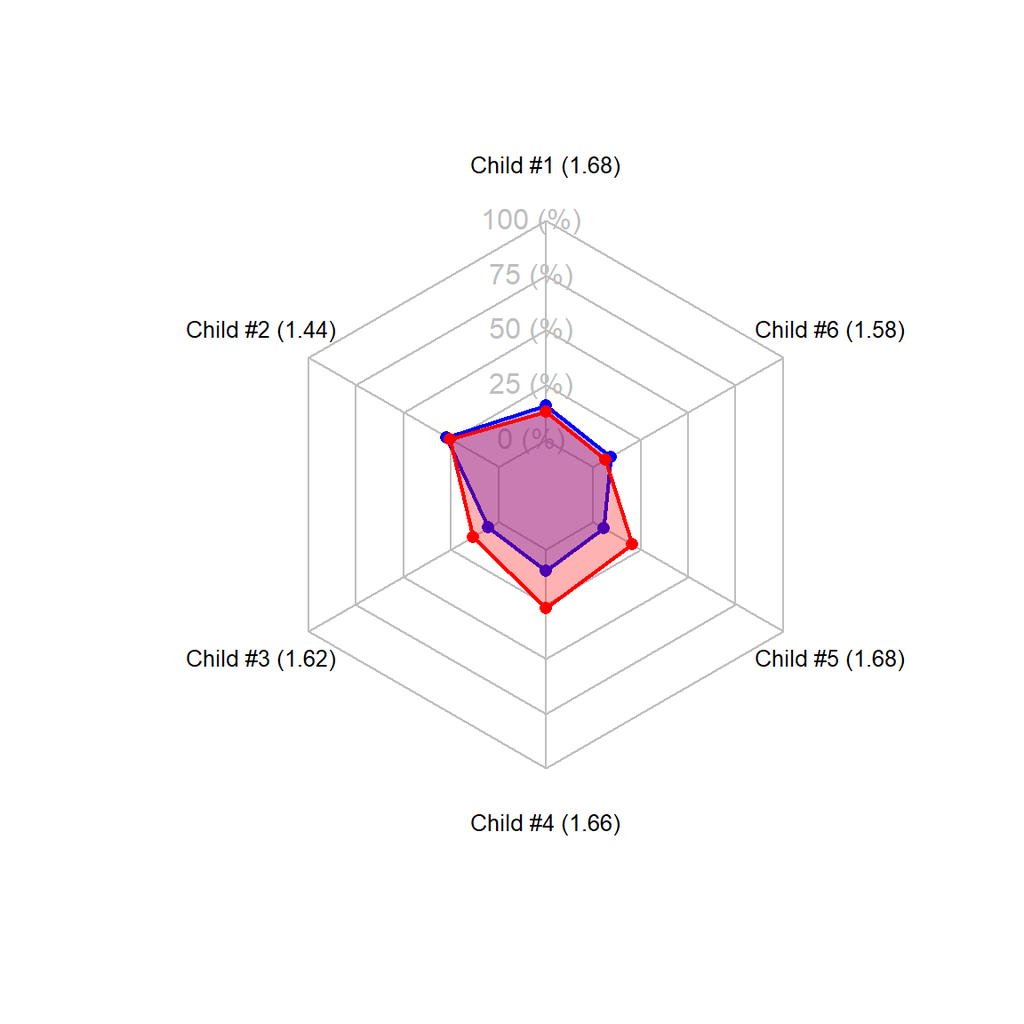

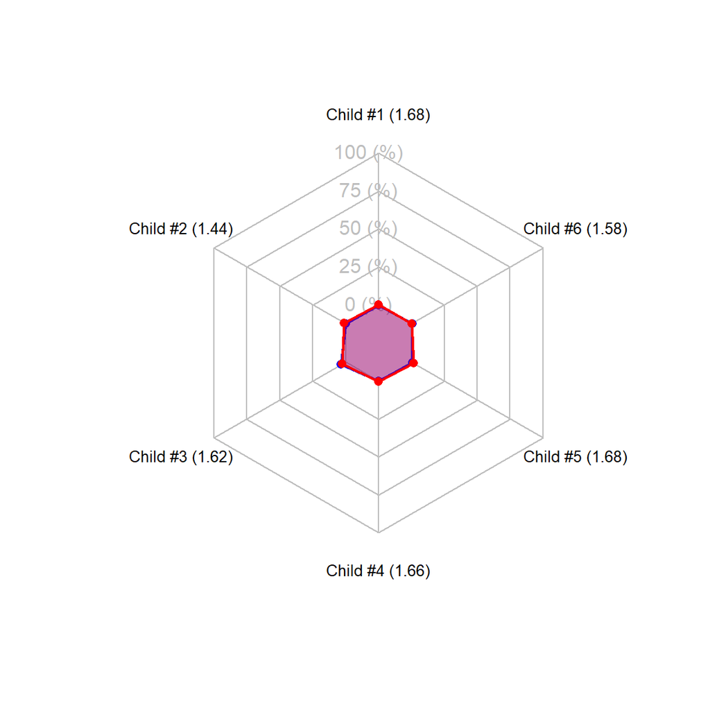

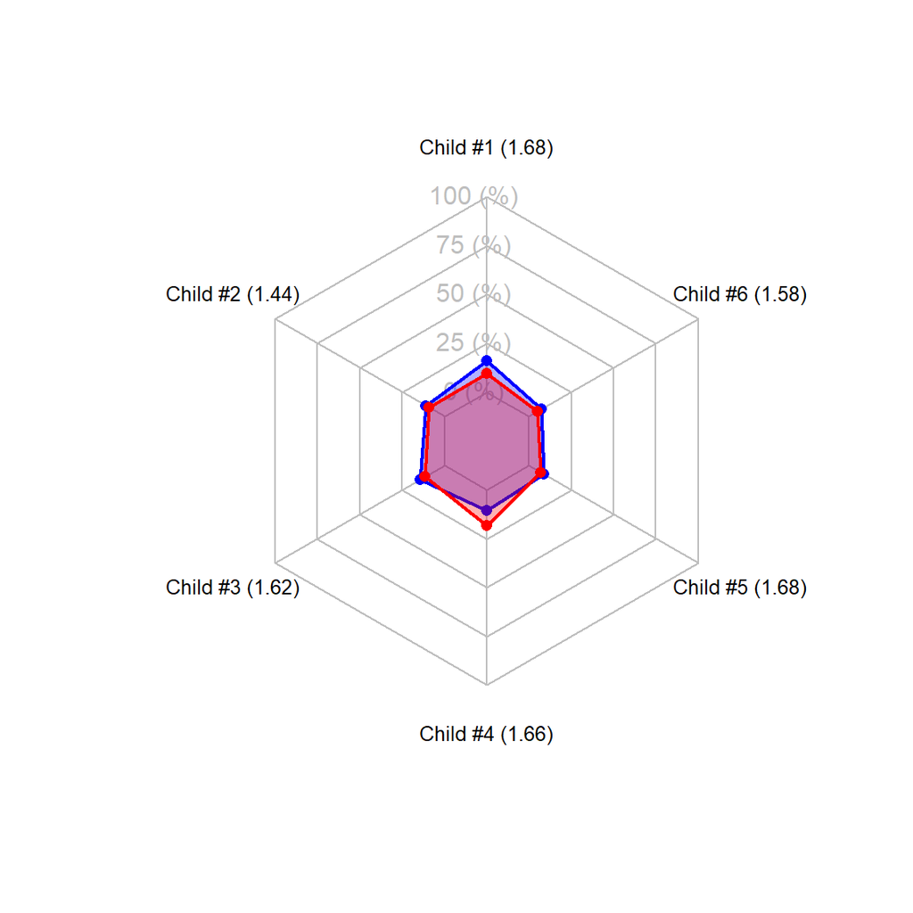

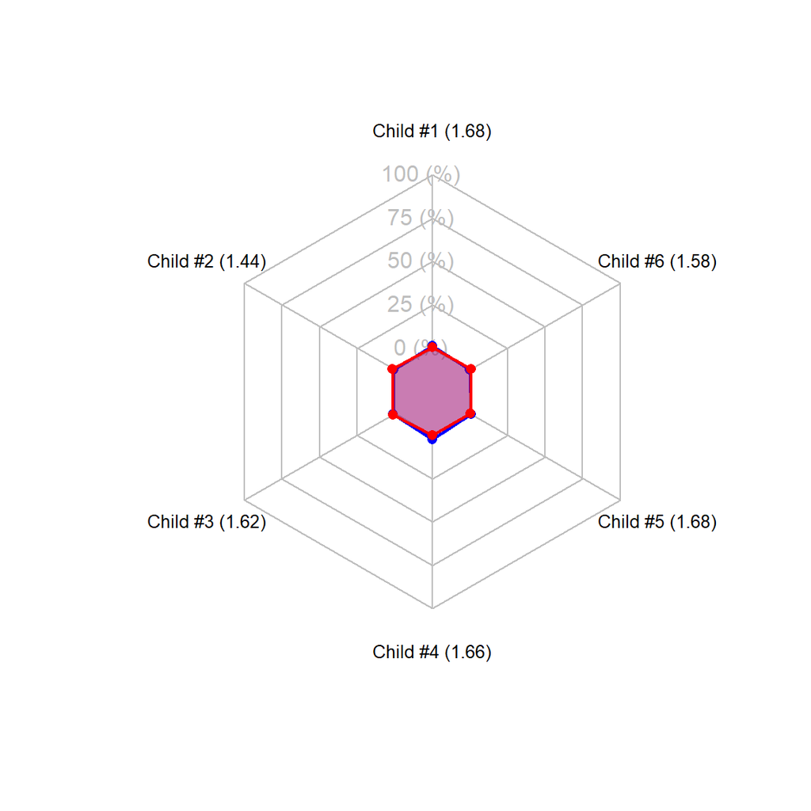

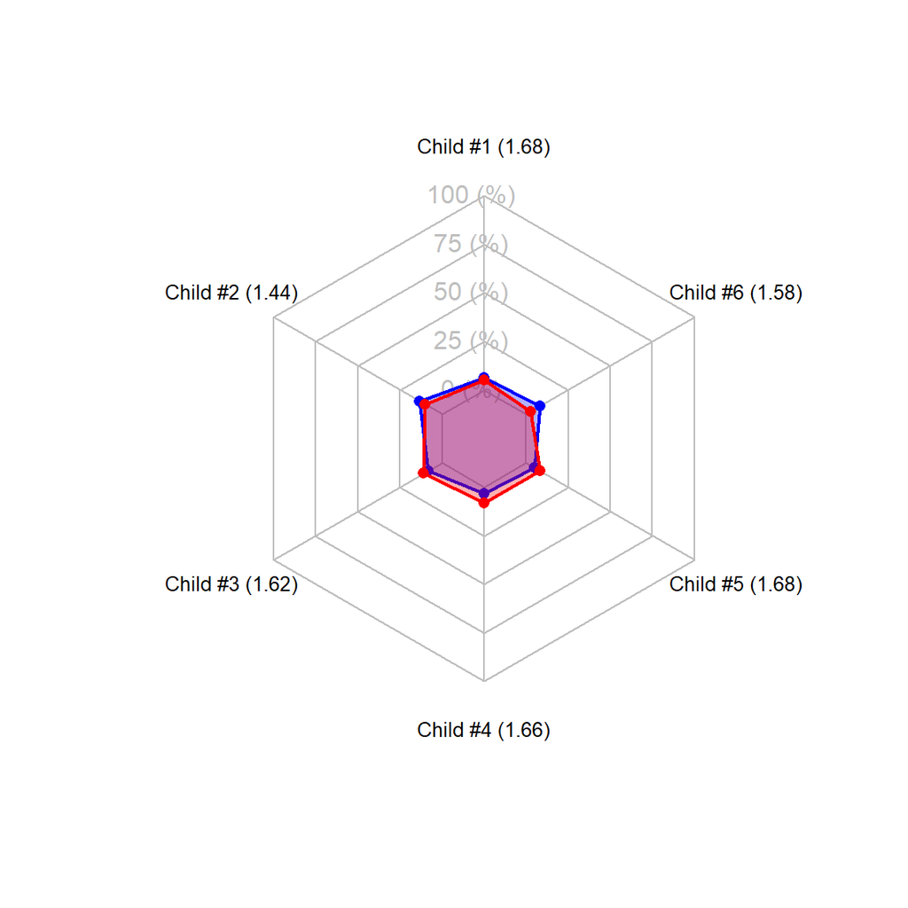

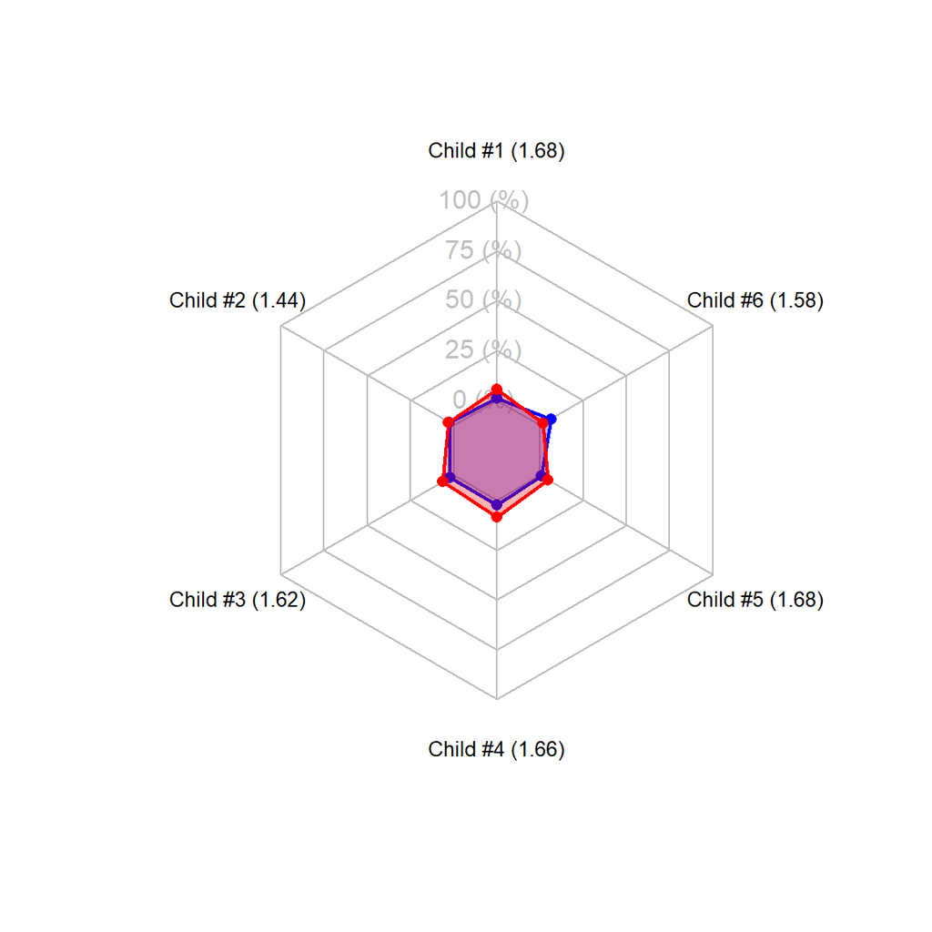

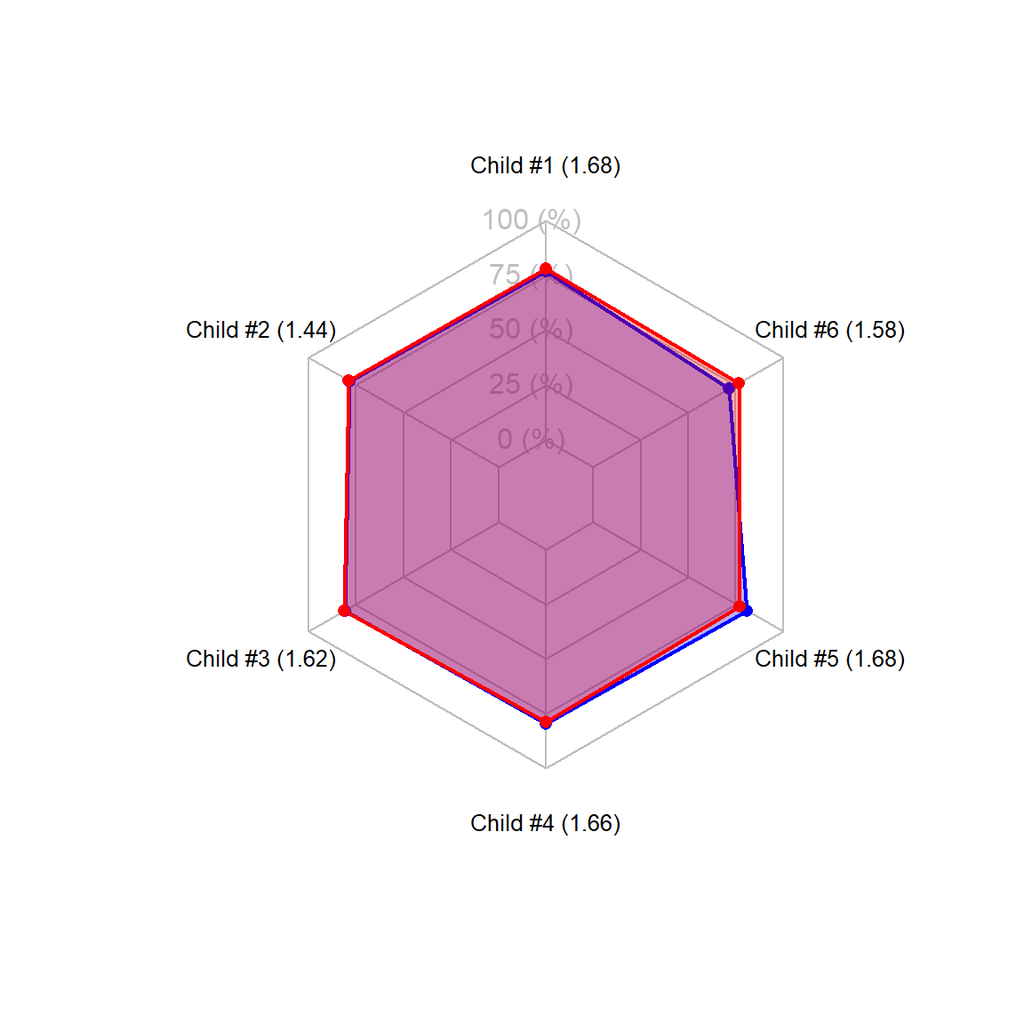

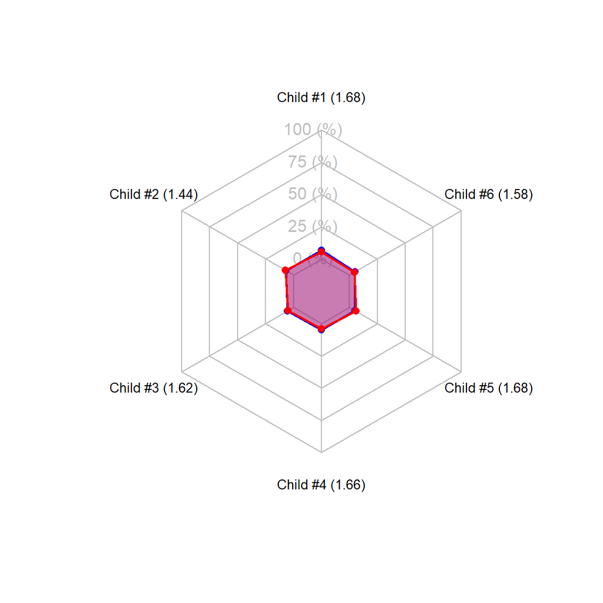

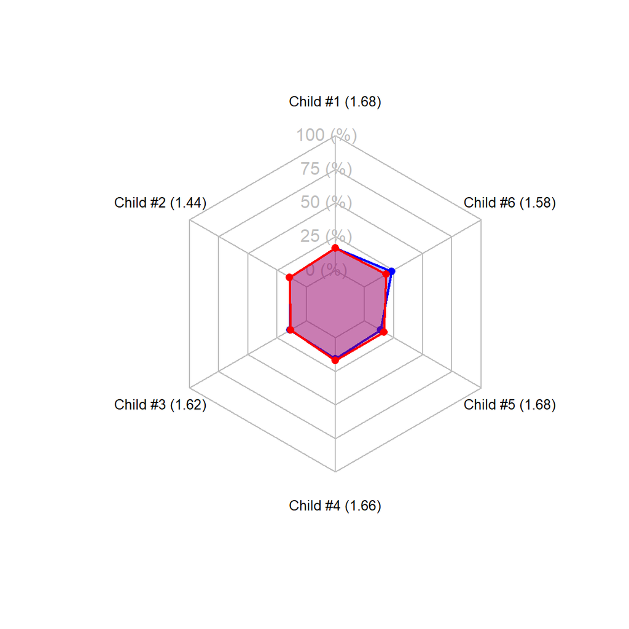

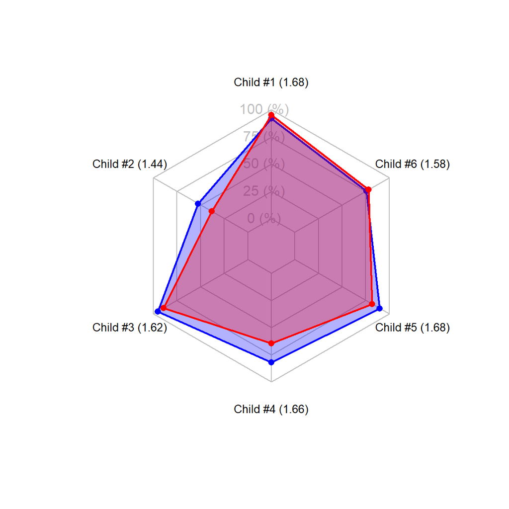

```r
if (!requireNamespace("fmsb", quietly = TRUE)) install.packages("fmsb")
library(fmsb)
library(dplyr)
library(tidyr)

# Create output folder if needed
if (!dir.exists("figs")) dir.create("figs")

# Load data
df <- read.csv("~/GitHub/Circle-Time-Data-Analyses/CircleTimeData-VBMAPP.csv")
df$Condition <- factor(df$Condition, levels = c(1, 2), labels = c("Human", "Robot"))

# Compute VB-MAPP per subject
vbmapp_scores <- df %>%
  group_by(Subject) %>%
  summarise(VBMAPP = mean(VBMAPP, na.rm = TRUE), .groups = "drop")

# Metrics list
metrics <- c(
  "Affect_Positive", "Affect_Negative",
  "Communication_with_Instructor", "Communication_with_Instructor_Prompted",
  "Communication_with_Therapist", "Communication_with_Indeterminent",
  "Engagement_OnTarget", "Engagement_Therapist", "Engagement_OffTarget",
  "Performance_Positive"
)

# Loop through each metric
for (metric in metrics) {
  avg_df <- df %>%
    group_by(Subject, Condition) %>%
    summarise(value = mean(.data[[metric]], na.rm = TRUE), .groups = "drop") %>%
    pivot_wider(names_from = Condition, values_from = value) %>%
    inner_join(vbmapp_scores, by = "Subject")

  if (any(!c("Human", "Robot") %in% colnames(avg_df))) next

  avg_df <- avg_df[order(avg_df$Subject), ]
  human <- avg_df$Human
  robot <- avg_df$Robot

  # Update axis labels to use "Child #" format
  axis_labels <- paste0("Child #", avg_df$Subject, " (", round(avg_df$VBMAPP, 2), ")")

  data <- as.data.frame(rbind(
    rep(1, length(human)),
    rep(0, length(human)),
    human,
    robot
  ))
  colnames(data) <- axis_labels
  rownames(data) <- c("Max", "Min", "Human", "Robot")


  # Save to PDF
  file_name <- paste0("figs/radar_", metric, ".pdf")
  pdf(file_name, width = 5, height = 5, useDingbats = FALSE)
  par(mar = c(1, 1, 1, 1))  # tight margins
  radarchart(data,
    axistype = 1,
    pcol = c("blue", "red"),
    pfcol = c(rgb(0, 0, 1, 0.3), rgb(1, 0, 0, 0.3)),
    plwd = 2,
    plty = 1,
    cglcol = "grey",
    cglty = 1,
    axislabcol = NA,   # remove axis labels
    vlcex = 0.8,
    title = ""
  )
  dev.off()


  # Also display in RMarkdown output
  radarchart(data,
    axistype = 1,
    pcol = c("blue", "red"),
    pfcol = c(rgb(0, 0, 1, 0.3), rgb(1, 0, 0, 0.3)),
    plwd = 2,
    plty = 1,
    cglcol = "grey",
    cglty = 1,
    axislabcol = "grey",
    vlcex = 0.8,
    title = ""  # No title
  )
}
```